# 9. Judging Model Effectiveness

Russ Conte

2022-05-27

# Judging Model Effectiveness

Start by loading the required packages in two lines of code:

```r
Packages <- c("tidymodels", "caret", "multilevelmod", "lme4", "VCA", "survival", "patchwork", "splines")
lapply(Packages, library, character = TRUE)
```

```
## • Use tidymodels_prefer() to resolve common conflicts.
```

[output not shown]

[output cut: 60 more lines]

```r
tidymodels_prefer(quiet = FALSE)
```

```
## [conflicted] Will prefer dplyr::filter over any other package
```

[output not shown]

Start with code for multi-core processing

```r
library(doParallel)
cl <- makePSOCKcluster(10)
registerDoParallel(cl)
```

```r
library(tidymodels)
data(ames)
ames <- mutate(ames, Sale_Price = log10(Sale_Price))

set.seed(502)
ames_split <- initial_split(ames, prop = 0.80, strata = Sale_Price)
ames_train <- training(ames_split)
ames_test  <-  testing(ames_split)

ames_rec <-
  recipe(Sale_Price ~ Neighborhood + Gr_Liv_Area + Year_Built + Bldg_Type +
           Latitude + Longitude, data = ames_train) %>%
  step_log(Gr_Liv_Area, base = 10) %>%
  step_other(Neighborhood, threshold = 0.01) %>%
  step_dummy(all_nominal_predictors()) %>%
  step_interact( ~ Gr_Liv_Area:starts_with("Bldg_Type_") ) %>%
  step_ns(Latitude, Longitude, deg_free = 20)

lm_model <- linear_reg() %>% set_engine("lm")

lm_workflow <-
  workflow() %>%
  add_model(lm_model) %>%
  add_recipe(ames_rec)

lm_fit <- fit(lm_workflow, ames_train)
```

Once we have a model, we need to know how well it works. A quantitative approach for estimating effectiveness allows us to understand the model, to compare different models, or to tweak the model to improve performance. Our focus in tidy models is an empirical validation; this usually means using data that were not used to create the model as the substrate to measure effectiveness.

The best approach to empirical validation involves using *resampling* methods that will be introduced in chapter 10. In this chapter, we motivate the need for empirical validation by using the test set. Keep in mind that the tests that can only be used once, is explained in section 5.1.

## 9.1 Performance Metrics and Inference

The effectiveness of any given model depends on how the model will be used. An inferential model is used primarily to understand relationships, and typically emphasizes the choice (and validity) of probabilistic distributions and other generative qualities that define the model.

For a model used primarily for prediction, by contrast, predictive strength is of primary importance and other concerns about underlying statistical qualities may be less important. Predictive strength is usually determined by how close our predictions come to the observed data, i.e. fidelity of the model predictions to the actual results. This chapter focuses on functions that can be used to measure predictive strength. However, our advice for those developing inferential models is to use these techniques even when the model will not be used with the primary goal of prediction.

In the remainder of the chapter, we will discuss general approaches for evaluating models by empirical validation. These approaches are grouped by the nature of the outcome data: purely numeric, binary classes, and three or more class levels.

## 9.2 Regression Metrics

To illustrate regression metrics, let’s check the model from section 8.8. This model `lm_workflow_fit` combines a linear regression model with a predictor set supplemented with an interaction and spline functions for longitude and latitude. It was created from a training set (named `Ames_train`). Although we do not advise using the test site at this juncture of the modeling process, it will be used here to illustrate functionality and syntax. The data frame `Ames_test` consists of 588 properties. To start, let’s produce predictions:

```r
ames_test_res <- predict(lm_fit, new_data = ames_test %>%  select(-Sale_Price))
ames_test_res
```

```
## # A tibble: 588 × 1
##    .pred
##    <dbl>
##  1  5.07
##  2  5.31
##  3  5.28
##  4  5.33
##  5  5.30
##  6  5.24
##  7  5.67
##  8  5.52
##  9  5.34
## 10  5.00
## # … with 578 more rows
```

The predicted numeric outcome from the regression model is names `.pred`. Let’s match the predicted values with their corresponding observed outcome values:

```r
ames_test_res <- bind_cols(ames_test_res, ames_test %>% select(Sale_Price))
ames_test_res
```

```
## # A tibble: 588 × 2
##    .pred Sale_Price
##    <dbl>      <dbl>
##  1  5.07       5.02
##  2  5.31       5.39
##  3  5.28       5.28
##  4  5.33       5.28
##  5  5.30       5.28
##  6  5.24       5.26
##  7  5.67       5.73
##  8  5.52       5.60
##  9  5.34       5.32
## 10  5.00       4.98
## # … with 578 more rows
```

We see that these values mostly look close, but we don’t yet have a quantitative understanding of how the model is doing because we haven’t computed any performance metrics. Note that both the predicted and observed outcomes are in log-10 units. It is best practice to analyze the predictions on the transformed scale (if one were used) even if the predictions are reported using original units.

Let’s plot the data in figure 9.2 before computing metrics:

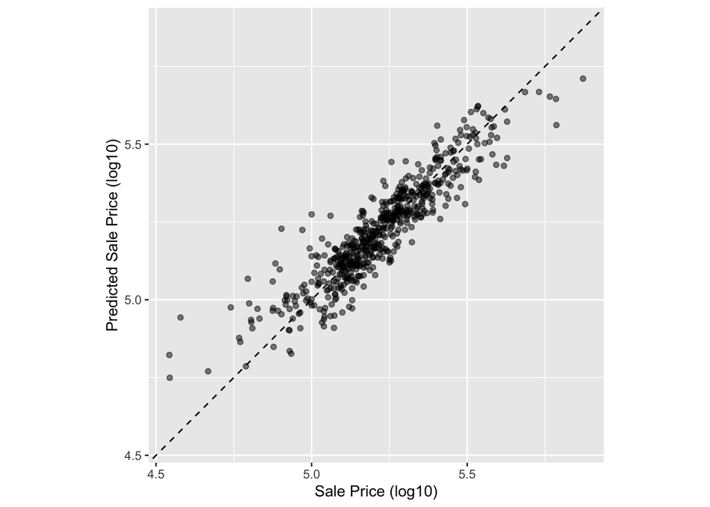

```r
ggplot(ames_test_res, aes(x = Sale_Price, y = .pred)) +
  # Create a diagonal line
  geom_abline(lty = 2) +
  geom_point(alpha = 0.5) +
  labs(y = "Predicted Sale Price (log10)", x = "Sale Price (log10)") +
  # Scale and size the x- and y- axes uniformly:
  coord_obs_pred()
```

Let’s compute the root mean squared error for this model using the `rmse()` function:

```r
rmse(ames_test_res, truth = Sale_Price, estimate = .pred)
```

```
## # A tibble: 1 × 3
##   .metric .estimator .estimate
##   <chr>   <chr>          <dbl>
## 1 rmse    standard      0.0736
```

This shows us the standard format of the output of **yardstick** functions. Metrics for numeric outcomes usually have a “standard” for the `.estimator` column. Examples with different values for this column are shown in the next sections.

To compute multiple metrics at once, we can create a *metric set*. Let’s add $R^2$ and the mean absolute error:

```r
ames_metrics <- metric_set(rmse, rsq, mae)
ames_metrics(ames_test_res, truth = Sale_Price, estimate = .pred)
```

```
## # A tibble: 3 × 3
##   .metric .estimator .estimate
##   <chr>   <chr>          <dbl>
## 1 rmse    standard      0.0736
## 2 rsq     standard      0.836
## 3 mae     standard      0.0549
```

## 9.3 Binary Classification Metrics

To illustrate other ways to measure model performance, we will switch to a different example. The **modeldata** package (another one of the tidymodels packages) contains example predictions from a test data set with two classes (“Class 1” and “Class 2”):

```r
data("two_class_example")
tibble(two_class_example) %>%
  map_dbl(mean)
```

```
##     truth    Class1    Class2 predicted
##        NA 0.5447397 0.4552603        NA
```

For the hard class predictions, a variety of **yardstick** functions are helpful:

Confusion matrix:

```r
conf_mat(two_class_example, truth = truth, estimate = predicted)
```

```
##           Truth
## Prediction Class1 Class2
##     Class1    227     50
##     Class2     31    192
```

Accuracy:

```r
accuracy(two_class_example, truth, predicted)
```

```
## # A tibble: 1 × 3
##   .metric  .estimator .estimate
##   <chr>    <chr>          <dbl>
## 1 accuracy binary         0.838
```

Matthew’s Correlation Coefficient:

```r
mcc(two_class_example, truth, predicted)
```

```
## # A tibble: 1 × 3
##   .metric .estimator .estimate
##   <chr>   <chr>          <dbl>
## 1 mcc     binary         0.677
```

F1 metric:

```r
f_meas(two_class_example, truth, predicted)
```

```
## # A tibble: 1 × 3
##   .metric .estimator .estimate
##   <chr>   <chr>          <dbl>
## 1 f_meas  binary         0.849
```

Combining these three classification metrics together:

```r
classification_metrics <- metric_set(accuracy, mcc, f_meas)
classification_metrics(two_class_example, truth = truth, estimate = predicted)
```

```
## # A tibble: 3 × 3
##   .metric  .estimator .estimate
##   <chr>    <chr>          <dbl>
## 1 accuracy binary         0.838
## 2 mcc      binary         0.677
## 3 f_meas   binary         0.849
```

The Matthews correlation coefficient and F1 score both summarize the confusion matrix, but compared to `mcc()`, which measures the quality of both positive and negative examples, the `f_meas()` metric emphasizes the positive class, i.e., the event of interest. For binary classification data sets like this example, yardstick functions have a standard argument called `event_level` to distinguish positive and negative levels. The default (which we used in this code) is that the first level of the outcome factor is the event of interest.

For example, the receiver operating characteristic (ROC) curve computes the sensitivity and specificity over a continuum of different event thresholds. The predicted class column is not used. There are two **yardstick** functions for this method: `roc_curve()` computes the data points that make up the ROC curve and `roc_auc()` computes the area under the curve.

The interfaces to these types of metric functions use the `...` argument placeholder to pass in the appropriate class probability column. For two-class problems, the probability column for the event of interest is passed into the function:

```r
two_class_curve <- roc_curve(two_class_example, truth, Class1)
two_class_curve
```

```
## # A tibble: 502 × 3
##    .threshold specificity sensitivity
##         <dbl>       <dbl>       <dbl>
##  1 -Inf           0                 1
##  2    1.79e-7     0                 1
##  3    4.50e-6     0.00413           1
##  4    5.81e-6     0.00826           1
##  5    5.92e-6     0.0124            1
##  6    1.22e-5     0.0165            1
##  7    1.40e-5     0.0207            1
##  8    1.43e-5     0.0248            1
##  9    2.38e-5     0.0289            1
## 10    3.30e-5     0.0331            1
## # … with 492 more rows
```

Let’s estimate the ROC curve:

```r
roc_auc(two_class_example, truth, Class1)
```

```
## # A tibble: 1 × 3
##   .metric .estimator .estimate
##   <chr>   <chr>          <dbl>
## 1 roc_auc binary         0.939
```

Let’s look at the ROC curve:

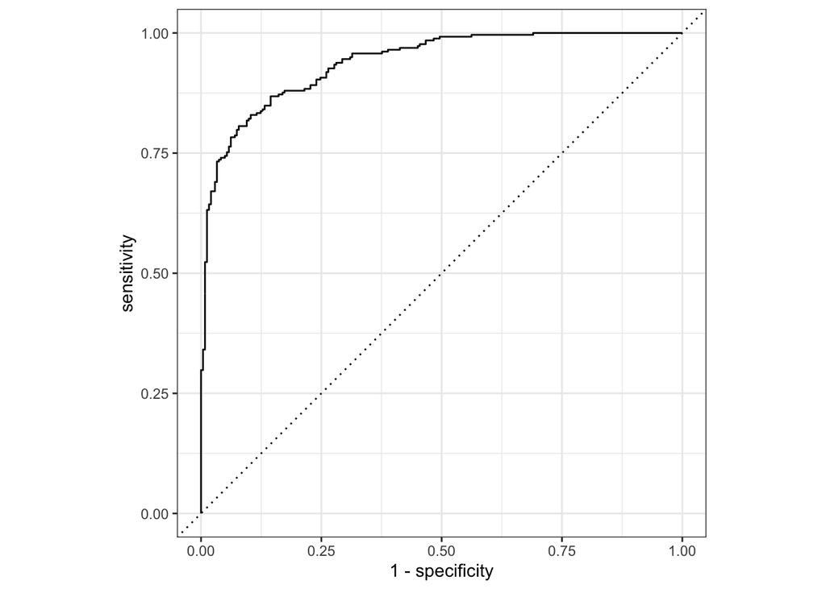

```r
autoplot(two_class_curve)
```

If the curve was close to the diagonal line, then the models predictions would be no better than random guessing. Since the curve is in the top, left – hand corner, we see that our model performs well at different thresholds.

There are a number of other functions that use probability estimates, including `gain_curve()`, `lift_curve()`, and `pr_curve()`

## 9.4 Multiclass Classification Metrics

What about data with three or more classes? To demonstrate, let’s explore a different example data set that has four classes:

```r
data("hpc_cv")
tibble(hpc_cv)
```

```
## # A tibble: 3,467 × 7
##    obs   pred     VF      F       M          L Resample
##    <fct> <fct> <dbl>  <dbl>   <dbl>      <dbl> <chr>
##  1 VF    VF    0.914 0.0779 0.00848 0.0000199  Fold01
##  2 VF    VF    0.938 0.0571 0.00482 0.0000101  Fold01
##  3 VF    VF    0.947 0.0495 0.00316 0.00000500 Fold01
##  4 VF    VF    0.929 0.0653 0.00579 0.0000156  Fold01
##  5 VF    VF    0.942 0.0543 0.00381 0.00000729 Fold01
##  6 VF    VF    0.951 0.0462 0.00272 0.00000384 Fold01
##  7 VF    VF    0.914 0.0782 0.00767 0.0000354  Fold01
##  8 VF    VF    0.918 0.0744 0.00726 0.0000157  Fold01
##  9 VF    VF    0.843 0.128  0.0296  0.000192   Fold01
## 10 VF    VF    0.920 0.0728 0.00703 0.0000147  Fold01
## # … with 3,457 more rows
```

```r
hpc_cv %>%
  select(where(is.numeric)) %>%
  map_dbl(mean)
```

```
##         VF          F          M          L
## 0.52600310 0.31342262 0.10093906 0.05963521
```

The functions for metrics that use the discrete class predictions are identical to their binary counterparts:

```r
accuracy(hpc_cv, obs, pred)
```

```
## # A tibble: 1 × 3
##   .metric  .estimator .estimate
##   <chr>    <chr>          <dbl>
## 1 accuracy multiclass     0.709
```

```r
mcc(hpc_cv, obs, pred)
```

```
## # A tibble: 1 × 3
##   .metric .estimator .estimate
##   <chr>   <chr>          <dbl>
## 1 mcc     multiclass     0.515
```

There are wrapper methods that can be used to apply sensitivity, the true positive rate, to our for class outcome. These options are macro-averaging, macro-weighted average in, and micro-averaging:

- Macro-averaging computes a set of one-versus-all metrics using the standard to class statistics. These are averaged.
- Macro – waited averaging does the same but the average is waited by the number of samples in each class
- Micro – averaging computes the contribution for each class, aggregates them, then compute a single metric from the aggregates.

**yardstick** can automatically apply these methods via the `estimator` argument:

```r
sens(hpc_cv, obs, pred, estimator = "macro")
```

```
## # A tibble: 1 × 3
##   .metric .estimator .estimate
##   <chr>   <chr>          <dbl>
## 1 sens    macro          0.560
```

```r
sens(hpc_cv, obs, pred, estimator = "macro_weighted")
```

```
## # A tibble: 1 × 3
##   .metric .estimator     .estimate
##   <chr>   <chr>              <dbl>
## 1 sens    macro_weighted     0.709
```

```r
sens(hpc_cv, obs, pred, estimator = "micro")
```

```
## # A tibble: 1 × 3
##   .metric .estimator .estimate
##   <chr>   <chr>          <dbl>
## 1 sens    micro          0.709
```

Note - there is another typo in the text, the function is `sens`, but the book has it as `sensitivity`.

```r
hpc_cv %>%
  group_by(Resample) %>%
  accuracy(obs, pred)
```

```
## # A tibble: 10 × 4
##    Resample .metric  .estimator .estimate
##    <chr>    <chr>    <chr>          <dbl>
##  1 Fold01   accuracy multiclass     0.726
##  2 Fold02   accuracy multiclass     0.712
##  3 Fold03   accuracy multiclass     0.758
##  4 Fold04   accuracy multiclass     0.712
##  5 Fold05   accuracy multiclass     0.712
##  6 Fold06   accuracy multiclass     0.697
##  7 Fold07   accuracy multiclass     0.675
##  8 Fold08   accuracy multiclass     0.721
##  9 Fold09   accuracy multiclass     0.673
## 10 Fold10   accuracy multiclass     0.699
```

The groupings also translate to the `autoplot()` methods with results shown in figure 9.4:

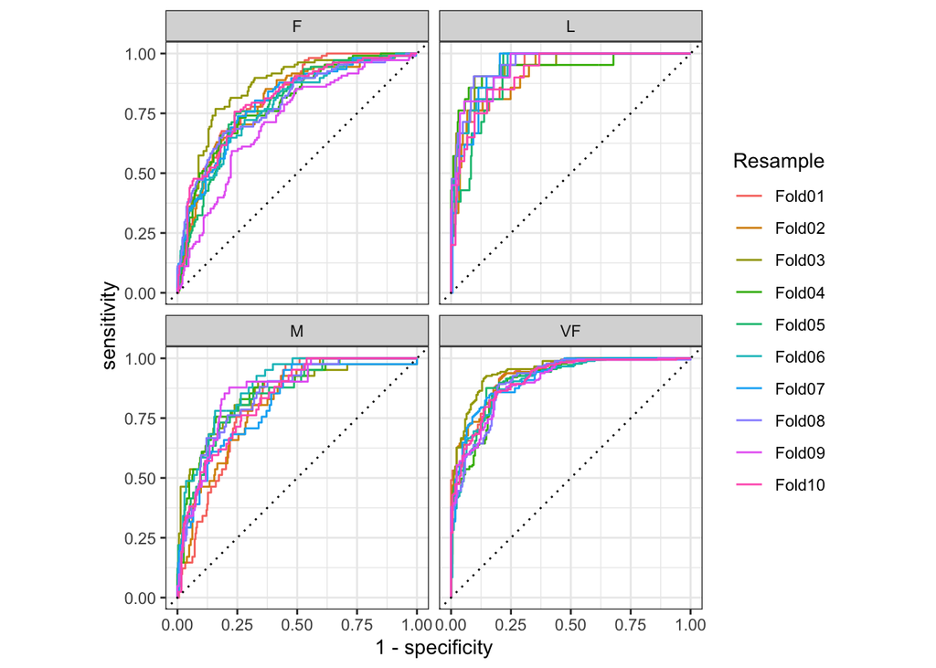

```r
hpc_cv %>%
  group_by(Resample) %>%
  roc_curve(obs, VF, F, M, L) %>%
  autoplot()
```

This visualization shows us that the different groups all perform about the same, but that the `VF` class is predicted better than th `F` or `M` classes, since the `VF` ROC curves are more in the top-left corner. This example uses resamples as the groups, but any grouping in your data can be used. This `autoplot()` method can be a quick visualization method for model effectiveness across outcome classes and/or groups.

## 9.5 Chapter Summary

Different metrics measure different aspects of a model fit, RMSE measures accuracy, while the $R^2$ Measures correlation. Measuring model performance is important even when a given model will not be used primarily for production; predictive power is also important for inferential or descriptive models.

Functions from the**yardstick**package special the effectiveness of a model using data. The prime tidy model interface uses tidy verse principles and data frames (as supposed to having vector arguments). Different metrics are appropriate for regression and classification metrics and, within these, there are sometimes different ways to estimate the statistics, such as for multi class outcomes.

REFERENCES

Craig–Schapiro, R, M Kuhn, C Xiong, E Pickering, J Liu, T Misko, R Perrin, et al. 2011. “Multiplexed Immunoassay Panel Identifies Novel CSF Biomarkers for Alzheimer’s Disease Diagnosis and Prognosis.” PLoS ONE 6 (4): e18850. Hand, D, and R Till. 2001. “A Simple Generalisation of the Area Under the ROC Curve for Multiple Class Classification Problems.” Machine Learning 45 (August): 171–86. Hosmer, D, and Sy Lemeshow. 2000. Applied Logistic Regression. New York: John Wiley; Sons. Jungsu, K, D Basak, and D Holtzman. 2009. “The Role of Apolipoprotein E in Alzheimer’s Disease.” Neuron 63 (3): 287–303. Opitz, J, and S Burst. 2019. “Macro F1 and Macro F1.” https://arxiv.org/abs/1911.03347. Wu, X, and Z Zhou. 2017. “A Unified View of Multi-Label Performance Measures.” In International Conference on Machine Learning, 3780–88.